# Assessment

Huw Riley

#Introduction

Paracetamol is a very common drug in the UK. while it can be obtained without prescription for significantly cheaper than it costs the NHS to supply through prescriptions, it still remains one of the most prescribed drugs in the UK. I will specifically be looking at the 500mg Paracetamol Tablets as this is the most common form found in shops as well as most commonly prescribed. I am aiming to look if any areas have higher rates of paracetamol prescription than others, if these areas have any trends in demographics and if there is a temporal aspect to the prescription.

```r
library(ggthemes)
library(tidyverse); theme_set(theme_linedraw())
library(janitor)
library(purrr)
library(sf)
library(patchwork)
library(gt)
library(readr)
library(ggiraph)
library(shiny)
#shiny package
#plotly
#consider using a graph where you can select specific health boards /  years
#style to csl document toformat html
#multiple hashtags make subheadings
#datatable
#gt
```

```r
url_loading <- function(url) {read_csv(url, show_col_types = FALSE) %>%
    clean_names()}

data_cleaning <- function(date, url) {
    url_loading(url)%>%
    mutate(dmd_code = as.character(dmd_code)) %>%
    filter(str_starts(bnf_item_code, "0407010H0")) %>%
    mutate(date = date) %>%
    mutate(date = as.Date(paste0(`date`, "/01"), format = "%m/%Y/%d"))}
```

```r
dates <- sprintf("%02d/2024", 1:12)
urls <- read_lines("links_clean.csv")

prescriptions_2024 <-map2_dfr(dates, urls, data_cleaning)
```

```r
hb_names <- url_loading("https://www.opendata.nhs.scot/dataset/9f942fdb-e59e-44f5-b534-d6e17229cc7b/resource/652ff726-e676-4a20-abda-435b98dd7bdc/download/hb14_hb19.csv") %>%
  select(hb, hb_name)

prescriptions_with_boards <- left_join(prescriptions_2024, hb_names, by =c("hbt"="hb"))

hb_population <- url_loading("https://www.opendata.nhs.scot/dataset/7f010430-6ce1-4813-b25c-f7f335bdc4dc/resource/27a72cc8-d6d8-430c-8b4f-3109a9ceadb1/download/hb2019_pop_est_03102025.csv") %>%
  filter(year == "2024", sex == "All")

full_prescritions_info <- left_join(prescriptions_with_boards, hb_population, by =c("hbt"="hb"))
```

## 1 Including Plots

```r
per_100k <- function(group){
  full_prescritions_info %>%
  filter(!is.na(hb_name)) %>%
  group_by(across(all_of(group))) %>%
  summarise(number_of_paid_items = sum(number_of_paid_items),
    population = mean(all_ages)) %>%
  mutate(items_per_100k = number_of_paid_items / population * 100000)}

Prescriptions_per_board <- per_100k("hb_name") %>%
  arrange(desc(items_per_100k)) %>%
   rename(Healthboard = hb_name, Prescriptions = number_of_paid_items, "Prescriptions Per 100,000 People" = items_per_100k) %>%
  gt() %>%
  tab_header(title = "Table of Yearly Prescriptions of Paracetamol Per year",
             subtitle = "Sorted by Prescriptions Per 100,000 People in Descending Order") %>%
  fmt_number(decimals = 0, use_seps = TRUE)
Prescriptions_per_board
```

Table of Yearly Prescriptions of Paracetamol Per year

Sorted by Prescriptions Per 100,000 People in Descending Order

| Healthboard | Prescriptions | population | Prescriptions Per 100,000 People |
| --- | --- | --- | --- |
| NHS Western Isles | 21,382 | 26,020 | 82,175 |
| NHS Shetland | 13,789 | 23,190 | 59,461 |
| NHS Dumfries and Galloway | 85,357 | 145,860 | 58,520 |
| NHS Fife | 205,177 | 374,760 | 54,749 |
| NHS Borders | 63,230 | 116,980 | 54,052 |
| NHS Orkney | 11,834 | 22,020 | 53,742 |
| NHS Ayrshire and Arran | 192,066 | 367,750 | 52,227 |
| NHS Greater Glasgow and Clyde | 593,536 | 1,217,270 | 48,760 |
| NHS Forth Valley | 148,042 | 306,340 | 48,326 |
| NHS Highland | 153,590 | 324,980 | 47,261 |
| NHS Tayside | 192,959 | 419,110 | 46,040 |
| NHS Grampian | 262,459 | 591,870 | 44,344 |
| NHS Lanarkshire | 300,834 | 678,570 | 44,334 |
| NHS Lothian | 319,973 | 932,180 | 34,325 |

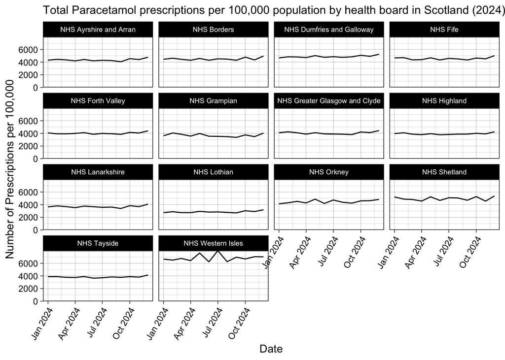

```r
paracetamol_per_board <- per_100k(c("hb_name", "date")) %>%
  ggplot(aes(x = date, y = items_per_100k)) +
  geom_line() +
  facet_wrap(~hb_name) +
  ggtitle("Total Paracetamol prescriptions per 100,000 population by health board in Scotland (2024)") +
  xlab("Date") +
  ylab("Number of Prescriptions per 100,000") +
  theme(axis.text.x = element_text(angle = 60, hjust = 1),
        plot.title = element_text(size=11.5), strip.text= element_text(size = 7)) +
  scale_y_continuous(expand = c(0, 0), limits = c(0, NA))
paracetamol_per_board
```

From this i can identify the health boards that prescribe the most paracetamol. for my next steps i will add the health board names in, use population data to check prescriptions per 100,000 people and then i will go on to compare the demographics of the health boards to see if there is an explanation of why there are differences. MAYBE LOOK AT PRESCRIPTIONS PER MONTH SEPARATELY

```r
zip_path <- paste0("/vsizip//vsicurl/", "https://maps.gov.scot/ATOM/shapefiles/SG_NHS_HealthBoards_2019.zip")
hb_shapes <- st_read(zip_path)

map <- hb_shapes %>%
  left_join(full_prescritions_info, by = c("HBCode" = "hbt"))
```

```r
map_of_prescriptions <- map %>%
   group_by(hb_name) %>%
  summarise(number_of_paid_items = sum(number_of_paid_items),
    population = mean(all_ages),
     geometry = first(geometry)) %>%
  mutate(items_per_100k = number_of_paid_items / population * 100000) %>%
  ggplot(aes(tooltip = hb_name, data_id = hb_name, fill = items_per_100k)) +
  geom_sf_interactive(colour = "black", size = 0.1) +
  scale_fill_distiller(palette = "Blues",
    direction = 1,
    name = "Prescriptions per 100k") +
  theme(plot.title = element_text(face = "bold", size = 10),
    plot.subtitle = element_text(size = 7))  +
  labs(title = "Paracetamol Prescriptions in Scotland",
    subtitle = "Yearly Number of Paracetamol Prescriptions Per 100k in Each Health Board in Scotland") +
  theme(plot.title = element_text(face = "bold", size = 10),
    plot.subtitle = element_text(size = 7))

map_2 <- map %>%
  mutate(over_65 = rowSums(across(86:111))) %>%
  mutate(percent_over_65 = (over_65 / all_ages)*100)

map_of_ages <- map_2 %>%
   group_by(hb_name) %>%
    summarise( number_of_paid_items = sum(number_of_paid_items),
    over_65 = mean(percent_over_65),
    geometry = first(geometry),) %>%
  ggplot(aes(tooltip = hb_name, data_id = hb_name, fill = over_65)) +
  geom_sf_interactive( colour = "black", size = 0.1) +
  scale_fill_distiller(
    palette = "Blues",
    direction = 1,
    name = "Percentage over 65") +
  labs(title = "Map of Older Populations in Scotland",
    subtitle = "Percentage of People 65 or Over in Each Health Board") +
  theme(plot.title = element_text(face = "bold", size = 10),
    plot.subtitle = element_text(size = 7))

interactive_map_of_prescriptions <- girafe(ggobj = map_of_prescriptions)
interactive_map_of_ages <- girafe(ggobj = map_of_ages)
together_maps <- fluidPage(fluidRow(column(6, girafeOutput("prescriptions")),
                                    column(6, girafeOutput("ages"))))
render <- function(input, output, session) {
  output$prescriptions <- renderGirafe({interactive_map_of_prescriptions})
  output$ages <- renderGirafe({interactive_map_of_ages})}
shinyApp(together_maps, render)
```

Shiny applications not supported in static R Markdown documents

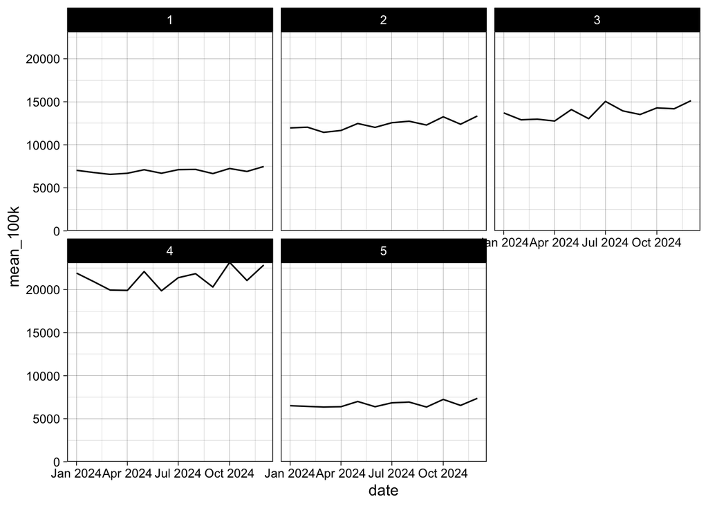

```r
simd <- url_loading("https://www.opendata.nhs.scot/dataset/78d41fa9-1a62-4f7b-9edb-3e8522a93378/resource/acade396-8430-4b34-895a-b3e757fa346e/download/simd2020v2_22062020.csv") %>%
  rename(quintiles = simd2020v2country_quintile) %>%
  select(quintiles, data_zone)

gps <- url_loading("https://www.opendata.nhs.scot/dataset/f23655c3-6e23-4103-a511-a80d998adb90/resource/47557411-7eda-4278-9d6d-d26ed2ceab5a/download/practice_contact_details_20251001_o.csv") %>%
  rename(gp_practice = practice_code) %>%
  left_join(simd, by = "data_zone") %>%
  filter(!(is.na(gp_practice)|is.na(quintiles)))

simd_paracetamol <-full_prescritions_info %>%
  left_join(gps, by = "gp_practice")


simd_paracetamol_graph <- simd_paracetamol %>%
  group_by(gp_practice_name, date) %>%
  summarise(items_per_100k = sum(paid_quantity / all_ages)*100000,
            quintiles = first(quintiles)) %>%
  group_by(quintiles, date) %>%
  summarise(mean_100k = mean(items_per_100k)) %>%
  filter(!is.na(quintiles)) %>%
  ggplot(aes(x = date, y = mean_100k)) +
  geom_line() +
  facet_wrap(~quintiles) +
  scale_y_continuous(expand = c(0, 0), limits = c(0, NA))
simd_paracetamol_graph
```